# Wildlife Population Trends Across Ecosystems

Arjun Sharma

September 2026

# 1 Abstract

Wildlife populations are monitored using many different measurement methods, making direct comparisons difficult. This analysis examines how monitored wildlife populations changed over time and whether those patterns differed among freshwater, marine, and terrestrial ecosystems.

To make populations comparable, each population was converted to an index where its first observed value was set to 100. Population trends were then compared during the first 20 years after monitoring began.

The analysis found distinct descriptive patterns among ecosystem types. Marine populations showed a substantial decline in median population index, freshwater populations showed an initial decline followed by recovery, and the terrestrial median remained close to its baseline.

# 2 1. Introduction

Wildlife monitoring datasets contain populations collected from different locations, species, ecosystems, and measurement systems.

This creates an important statistical problem: a population measured in “number of individuals” cannot be directly averaged with one measured in “breeding pairs” or another measured using an abundance index.

The central research question of this analysis is:

> **How have monitored wildlife populations changed over time, and do these changes differ across ecosystem types?**

# 3 2. Data

The analysis uses the Living Planet Database.

The original dataset contains wildlife population observations across the years 1950 through 2020 and includes information such as species, geographic region, ecosystem type, location, and measurement units.

```r
wildlife <- read_csv(
  "LPD_2024_public.csv",
  na = c("NULL", ""),
  show_col_types = FALSE
) |>
  select(-`...103`)
```

```r
tibble(
  `Population records` = nrow(wildlife),
  `Original variables` = ncol(wildlife),
  `First year` = 1950,
  `Last year` = 2020
) |>
  kable()
```

| Population records | Original variables | First year | Last year |
| --- | --- | --- | --- |
| 35996 | 102 | 1950 | 2020 |

The dataset contains three ecosystem categories:

```r
wildlife |>
  count(System) |>
  kable(
    col.names = c("Ecosystem", "Population Records"),
    caption = "Population records by ecosystem"
  )
```

Population records by ecosystem

| Ecosystem | Population Records |
| --- | --- |
| Freshwater | 7880 |
| Marine | 16258 |
| Terrestrial | 11858 |

# 4 3. Data Preparation

## 4.1 3.1 Reshaping the Data

The original dataset stores every year in a separate column. For analysis, the data were converted from wide format into long format so that each row represents one population measurement in one year.

```r
wildlife_long <- wildlife |>
  pivot_longer(
    cols = `1950`:`2020`,
    names_to = "year",
    values_to = "population"
  ) |>
  mutate(
    year = as.numeric(year)
  )
```

## 4.2 3.2 Missing Population Measurements

```r
missing_summary <- wildlife_long |>
  summarize(
    Total = n(),
    Missing = sum(is.na(population)),
    Available = sum(!is.na(population))
  )

missing_summary |>
  kable(caption = "Availability of population measurements")
```

Availability of population measurements

| Total | Missing | Available |
| --- | --- | --- |
| 2555716 | 2135360 | 420356 |

A large proportion of the possible population-year combinations contain no measurement. Therefore, the amount of monitoring data available differs substantially across years.

# 5 4. Monitoring Coverage Over Time

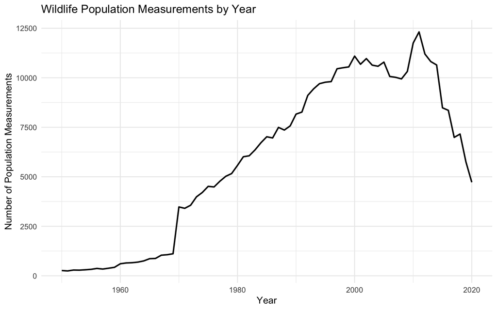

```r
year_counts <- wildlife_long |>
  filter(!is.na(population)) |>
  count(year)

ggplot(year_counts, aes(x = year, y = n)) +
  geom_line(linewidth = 0.8) +
  labs(
    x = "Year",
    y = "Number of Population Measurements",
    title = "Wildlife Population Measurements by Year"
  ) +
  theme_minimal()
```

This figure represents **monitoring coverage**, not wildlife abundance. A larger value means that more population measurements were available during that year.

# 6 5. Making Populations Comparable

The database contains many different measurement units. For example, some populations are represented by numbers of individuals while others use breeding pairs, abundance indices, or other sampling measures.

Directly averaging these measurements would therefore be inappropriate.

Instead, each population was converted into a relative population index:

$$\text{Population Index} =
\frac{\text{Population at time }t}
{\text{Initial Population}}
\times 100$$

An index of:

- **100** represents the starting level.
- **120** represents a value 20% above the starting level.
- **80** represents a value 20% below the starting level.

```r
wildlife_index <- wildlife_long |>
  filter(!is.na(population)) |>
  group_by(ID) |>
  arrange(year, .by_group = TRUE) |>
  mutate(
    first_population = first(population)
  ) |>
  filter(first_population > 0) |>
  mutate(
    population_index =
      (population / first_population) * 100
  ) |>
  filter(n() >= 2) |>
  mutate(
    first_year = first(year),
    years_since_start = year - first_year
  ) |>
  ungroup()
```

Populations whose initial measurement was zero were excluded because a relative index cannot be calculated using zero as the denominator. Populations with fewer than two measurements were also excluded because change over time could not be determined.

# 7 6. Ecosystem Population Trends

Because monitoring began in different calendar years for different populations, populations were aligned according to the number of years since monitoring began.

For every ecosystem and monitoring year, the **median population index** was calculated. The median was used instead of the mean because population indices can contain very large values and extreme changes.

```r
ecosystem_trends <- wildlife_index |>
  group_by(System, years_since_start) |>
  summarize(
    median_index =
      median(population_index, na.rm = TRUE),
    populations = n_distinct(ID),
    .groups = "drop"
  )
```

## 7.1 First 20 Years of Monitoring

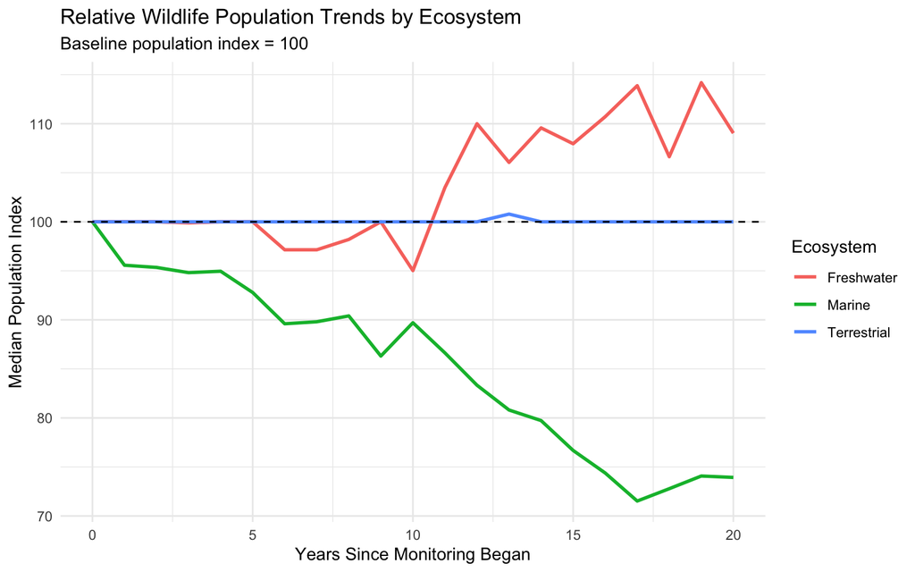

```r
ecosystem_trends |>
  filter(years_since_start <= 20) |>
  ggplot(
    aes(
      x = years_since_start,
      y = median_index,
      color = System
    )
  ) +
  geom_line(linewidth = 1) +
  geom_hline(
    yintercept = 100,
    linetype = "dashed"
  ) +
  labs(
    x = "Years Since Monitoring Began",
    y = "Median Population Index",
    color = "Ecosystem",
    title = "Relative Wildlife Population Trends by Ecosystem",
    subtitle = "Baseline population index = 100"
  ) +
  theme_minimal()
```

The three ecosystem categories show noticeably different descriptive patterns during the first 20 years of monitoring.

# 8 7. Comparison at Key Time Points

```r
milestone_trends <- ecosystem_trends |>
  filter(
    years_since_start %in%
      c(0, 5, 10, 15, 20)
  ) |>
  mutate(
    median_index = round(median_index, 1)
  )

milestone_trends |>
  kable(
    col.names = c(
      "Ecosystem",
      "Years Since Start",
      "Median Population Index",
      "Populations"
    ),
    caption =
      "Population trends at selected monitoring intervals"
  )
```

Population trends at selected monitoring intervals

| Ecosystem | Years Since Start | Median Population Index | Populations |
| --- | --- | --- | --- |
| Freshwater | 0 | 100.0 | 6356 |
| Freshwater | 5 | 100.0 | 3580 |
| Freshwater | 10 | 95.0 | 2628 |
| Freshwater | 15 | 108.0 | 1615 |
| Freshwater | 20 | 109.0 | 1314 |
| Marine | 0 | 100.0 | 13148 |
| Marine | 5 | 92.8 | 5781 |
| Marine | 10 | 89.7 | 5070 |
| Marine | 15 | 76.7 | 3887 |
| Marine | 20 | 73.9 | 3019 |
| Terrestrial | 0 | 100.0 | 10893 |
| Terrestrial | 5 | 100.0 | 5489 |
| Terrestrial | 10 | 100.0 | 4510 |
| Terrestrial | 15 | 100.0 | 3496 |
| Terrestrial | 20 | 100.0 | 2793 |

At 20 years, the median population index was approximately:

- **Freshwater:** 109
- **Marine:** 73.9
- **Terrestrial:** 100

Relative to their baseline, this corresponds to approximately a **9% increase for the freshwater median**, a **26.1% decrease for the marine median**, and little change in the terrestrial median.

These values describe the median monitored population and should not be interpreted as saying that every population within an ecosystem followed the same trajectory.

# 9 8. Variation Among Individual Populations

The median can hide substantial variation among individual populations. Therefore, populations with an observation exactly 20 years after monitoring began were classified according to their population index.

Populations within 10% of their starting value were classified as “Near baseline.”

```r
year20_distribution <- wildlife_index |>
  filter(years_since_start == 20) |>
  mutate(
    percent_change = population_index - 100,
    trend = case_when(
      population_index < 90 ~ "Decreased",
      population_index > 110 ~ "Increased",
      TRUE ~ "Near baseline"
    )
  )

trend_summary <- year20_distribution |>
  count(
    System,
    trend,
    name = "populations"
  ) |>
  group_by(System) |>
  mutate(
    percent =
      populations / sum(populations) * 100
  ) |>
  ungroup()
```

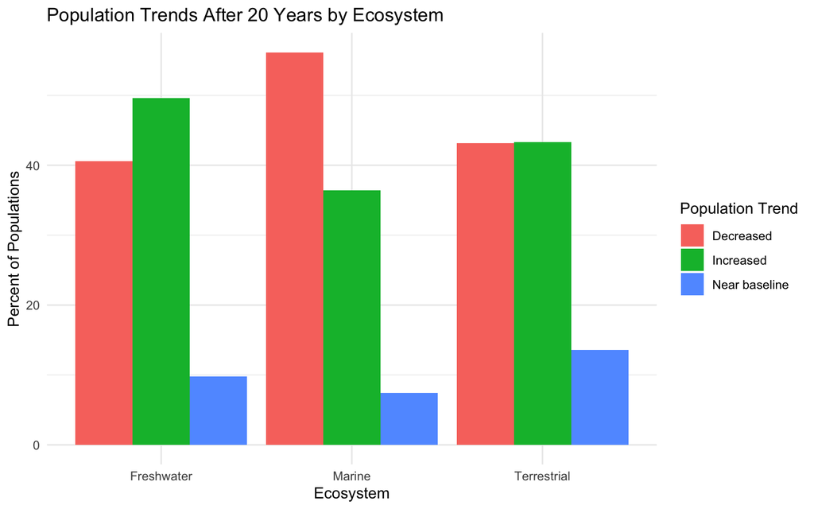

```r
ggplot(
  trend_summary,
  aes(
    x = System,
    y = percent,
    fill = trend
  )
) +
  geom_col(position = "dodge") +
  labs(
    x = "Ecosystem",
    y = "Percent of Populations",
    fill = "Population Trend",
    title =
      "Population Trends After 20 Years by Ecosystem"
  ) +
  theme_minimal()
```

# 10 9. Limitations

Several limitations should be considered when interpreting these results.

1. Populations whose first recorded value was zero were excluded because the relative population index cannot be calculated with a zero denominator.
2. Different populations were monitored for different lengths of time.
3. The number of populations contributing to the median decreases as the number of years since monitoring began increases.
4. The 20-year distribution analysis only includes populations with a measurement exactly 20 years after monitoring began.
5. The original studies used many different measurement units. Converting measurements to relative indices makes trends more comparable but does not eliminate all differences between monitoring methodologies.
6. The dataset is observational. The analysis identifies differences in observed population trends but does not establish that ecosystem type caused those differences.

# 11 10. Conclusion

Monitored wildlife populations displayed different relative trajectories across freshwater, marine, and terrestrial ecosystems during the first 20 years after monitoring began.

Marine populations showed the clearest decline, with the median population index falling from 100 to approximately 73.9. Freshwater populations initially declined before recovering to a median index of approximately 109. The terrestrial median remained close to its baseline value of 100.

These results indicate that population trajectories differ across the three ecosystem categories represented in the dataset. However, the substantial variation among individual populations and the observational nature of the data mean that these patterns should be interpreted descriptively rather than causally.

# 12 Technical Notes

The analysis was performed in R using the `tidyverse` and `ggplot2`. All transformations, population-index calculations, summaries, and figures were generated programmatically from the original dataset.